# Social Data Science - Is there division of social impact in Twitter?

Dr. David Garcia

In this exercise, we will test the hypothesis of division of impact from Social Impact Theory against data from US congress members on Twitter. This hypothesis states that the extent of social impact exercised by a source on each of the members of a group decreases with the size of the group (the number of targets). On Twitter, this happens when someone tweets to their followers (the group) and they retweet or not (social impact). The hypothesis implies that aggregating the total impact grows with the number of targets, but does so sublinearly, i.e. slower than a straight line.

We will use the official list of US Congress members on Twitter as of 2023, you can find the current list here: https://twitter.com/cspan/lists/members-of-congress/members. We will use a dataset of the latest tweets by these accounts in early February 2023, which you can find here: LINK. It is a static dataset that contains less than 50.000 public tweets posted by elected congress members in their official Twitter accounts and thus contain data that cannot considered private as they posted them as part of their public role. This dataset contains all public tweets by each congress member that were between one day and one month old when the data was retrieved, so you can assume that the number of retweets nor the number of followers would change a lot in this time period.

We will read this json dataset and inspect its content to then measure the number of followers of each user in the datest. Then we will study tweets by these users to calculate the average number of retweets they receive, as a measure of their social impact. We will fit a regression model of their impact as a function of their number of followers, and test this way if there is a sublinear (but positive) relationship between the size of their audience and the extent of their impact. In the end, we will assess the uncertainty in our estimate of the exponent of this relationship by bootstrapping.

## Tasks:

1. Reading US congress members tweets in JSON
2. Calculate relevant variables
3. Visualize distributions and scatter plots
4. Fit and visualize the regression model
5. Bootstrapping

# 1. Reading US congress members tweets in JSON

**1.1 Load jsonlite library**

If you have not installed the jsonlite library yet, do it with install.packages(). We will use this library to read the tweets JSON data. Also load the dplyr library, we will use it later.

```r
#install.packages(jsonlite)
library(jsonlite)
library(dplyr)
```

**1.2 Read tweets JSON data**

The tweets JSON data is compressed in the file USCongress-tweets.json.gz. Use gzfile and readLines to read all its content into one variable and then look at the content of a single line at random in the dataset. How does that look like?

```r
lines <- readLines(gzfile("USCongress-tweets.json.gz"))
lines[sample(length(lines), 1)]
```

```
## [1] "{\"created_at\":\"Mon Jan 09 23:56:39 +0000 2023\",\"id\":1612599260989780000,\"id_str\":\"1612599260989784066\",\"full_text\":\"I agree with my colleague from Maryland. We absolutely must rein in wasteful government spending. \\n\\nWe have a responsibility to protect taxpayer dollars withou…
```

**1.3 Convert one line from JSON**

Choose another random line in the variable with the file lines and parse its JSON content with the fromJSON file. Then look at its content and look for four pieces of information we are interested on: the id of the user that posted the tweet, the number of followers of that user, the number of retweets of the tweet, and if it was a retweet, the id of the retweeted tweet.

```r
tweet <- fromJSON(lines[sample(length(lines), 1)])

tweet$user$id_str
```

```
## [1] "61206798"
```

```r
tweet$user$followers_count
```

```
## [1] 116457
```

```r
tweet$retweet_count
```

```
## [1] 6
```

```r
tweet$retweeted_status$id_str
```

[output not shown]

**1.4 Convert the full dataset from JSON**

Now you can use what you did in the chunk above to go over each tweet in the dataset. Write a loop that goes over each line and checks if the tweet of that line is a retweet or not. If it is not a retweet, then save the id of the user that posted it, its number of followers, and the number of retweets of the tweet. Then save this information into a data frame with three columns, one for each variable.

```r
userids <- NULL
followercounts <- NULL
retweetscounts <- NULL
for (line in lines)
{
  tweet <- fromJSON(line)
  if (is.null(tweet$retweeted_status$id_str))
  {
    userids[length(userids)+1] <- tweet$user$id_str
    followercounts[length(followercounts)+1] <- tweet$user$followers_count
    retweetscounts[length(retweetscounts)+1] <- tweet$retweet_count
  }
}

tweetsdf <- data.frame(user_id=userids, followers_count=followercounts, retweet_count=retweetscounts)
```

# 2. Calculate relevant variables

**2.1 Filter the data frame**

Use pipes and the dplyr filter function to select only tweets with more than zero retweets and from accounts with more than zero followers.

```r
tweetsdf %>% filter(retweet_count>0, followers_count>0) -> tweetsdf2
```

How many tweets did you remove this way? How many users? Calculate that by comparing the number of rows and the number of unique user ids of the data frame before and after filtering.

```r
cat("number of tweets before:", nrow(tweetsdf), "\n")
```

```
## number of tweets before: 25677
```

```r
cat("number of tweets after:", nrow(tweetsdf2), "\n")
```

```
## number of tweets after: 23472
```

```r
cat("number of users before:", length(unique(tweetsdf$user_id)), "\n")
```

```
## number of users before: 505
```

```r
cat("number of users after:", length(unique(tweetsdf2$user_id)), "\n")
```

```
## number of users after: 505
```

**2.3 Aggregate and calculate user-level variables**

Now on the result, we want to calculate the mean number of retweets of each user, the total number of tweets of each user in the dataset, and also to save the number of followers of each user (for example, as the minimum among the tweets). Here group_by and summarise from dplyr will be helpful. Save the result in a data frame called usersdf and name the column with the mean number of retweets as mnRT.

```r
tweetsdf2 %>% group_by(user_id) %>% summarise(mnRT = mean(retweet_count), followers_count=min(followers_count), n=n()) -> usersdf
#Your code here
```

**2.3 Filter by number of tweets**

We want to make sure that our measurement of the number of retweets is accurate and some congress members might not have been active enough for us to measure that. Filter the users dataframe to make sure that each user has at least 20 tweets. How many users did you have before and after?

```r
usersdf %>% filter(n>=20) -> usersdf2
cat("number of users before:", nrow(usersdf), "\n")
```

```
## number of users before: 505
```

```r
cat("number of users after:", nrow(usersdf2), "\n")
```

```
## number of users after: 435
```

```r
usersdf <- usersdf2
```

# 3. Visualize distributions and scatter plots

**3.1 Distribution of the number of followers**

Plot the histogram of the number of followers of users in your dataset, and the histogram of the logarithm of the number of followers. Which one is more skewed?

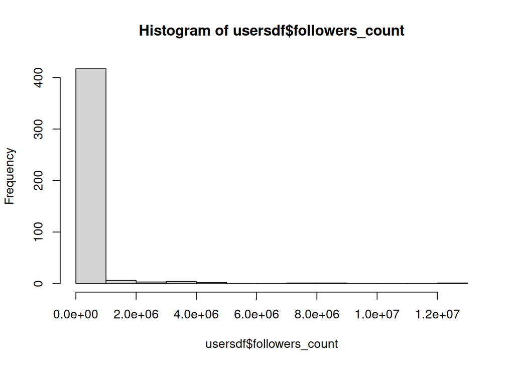

```r
hist(usersdf$followers_count)
```

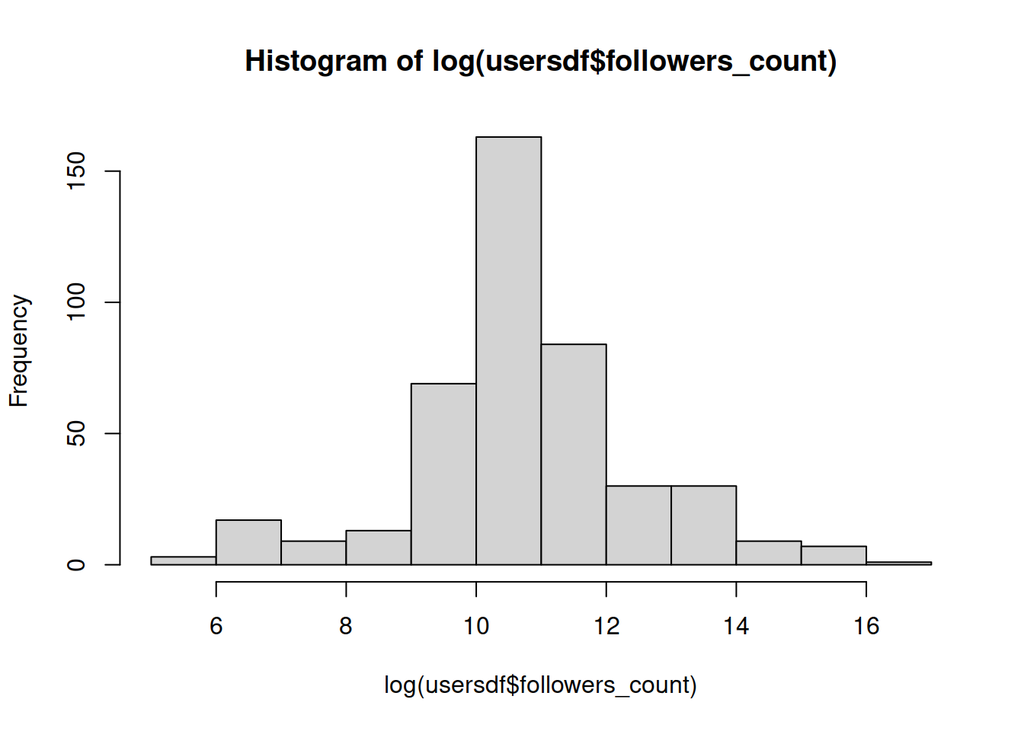

```r
hist(log(usersdf$followers_count))
```

```r
#Your code here
```

**3.2 Distribution of social impact**

Repeat the above point but for the social impact of your users, also computing the logarithm. Which one is more skewed?

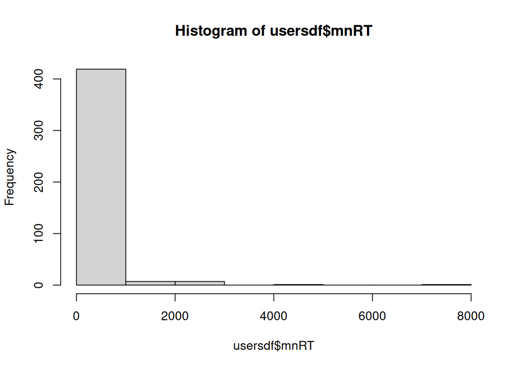

```r
hist(usersdf$mnRT)
```

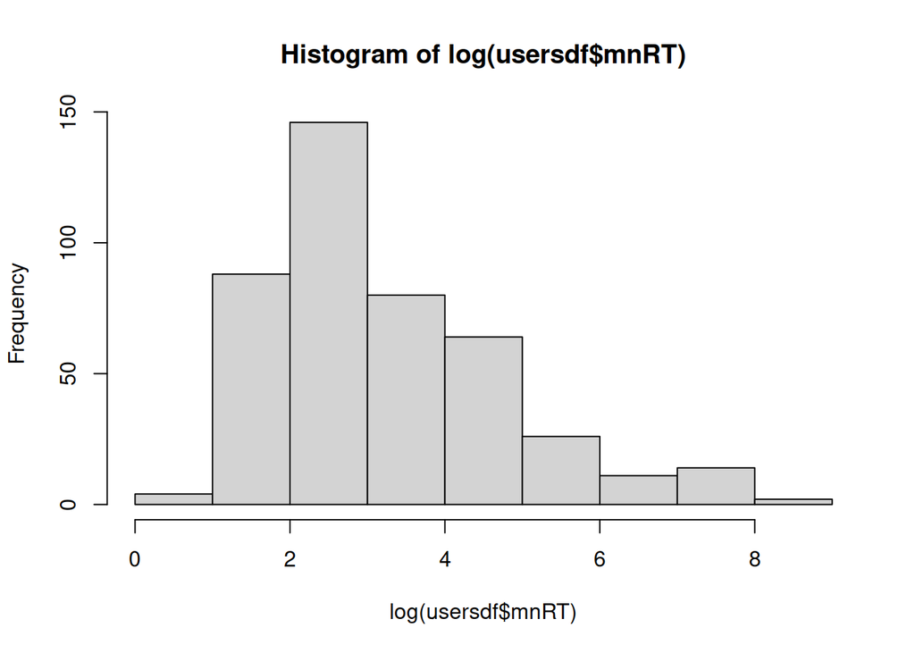

```r
hist(log(usersdf$mnRT))
```

```r
#Your code here
```

**3.3 Number of followers vs social impact**

Make a scatter plot with the logarithm of the number of followers of users on the horizontal axis and the logarithm of social impact on the vertical axis. Do you guess that there is a relationship?

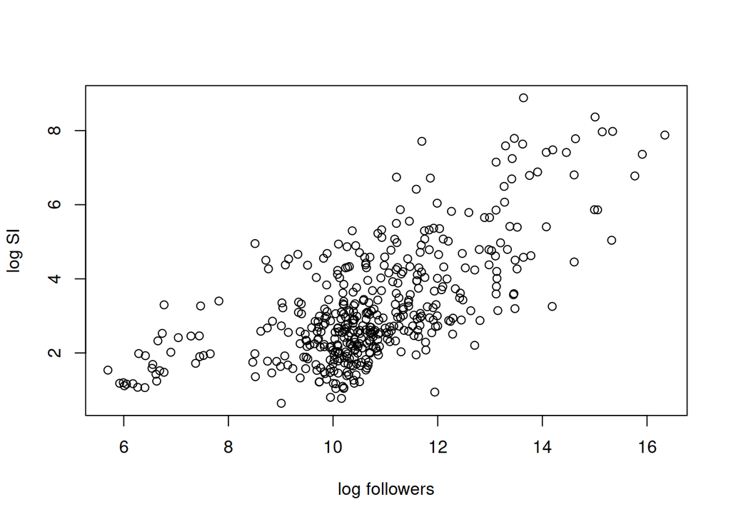

```r
plot(log(usersdf$followers_count), log(usersdf$mnRT), xlab="log followers", ylab="log SI")
```

```r
#Your code here
```

# 4. Fit and visualize the regression model

**4.1 Fit a linear model**

Make two new columns on the users data frame, one called SI with the logarithm of the number of retweets, and another called FC with the logarithm of the number of followers. Use the lm function to fit a model with the SI as dependent variable and FC as independent variable.

```r
usersdf$SI <- log(usersdf$mnRT)
usersdf$FC <- log(usersdf$followers_count)

model <- lm(SI ~ FC, data=usersdf)
#Your code here
```

Print the values of the coefficient estimates of the model. Do these values support or contradict Social Impact Theory?

```r
model$coefficients
```

```
## (Intercept)          FC
##  -3.1085943   0.5904448
```

```r
#Your code here
```

**4.2 Plot fit result**

Plot the same scatter plot as in 3.3. Then use the abline function to draw a line of top with the intercept being the first coefficient of the model, and the slope as the second coefficient of the model. Add a second line with the same intercept but slope 1. Which slope do you think is closer to the slope you see in the scatter plot?

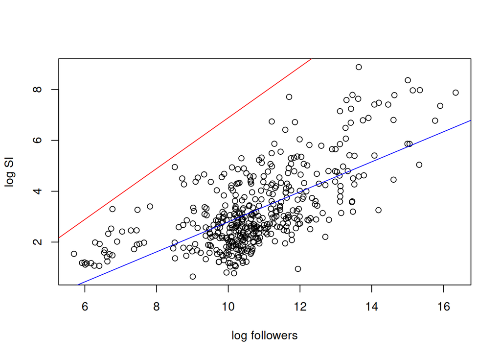

```r
plot(log(usersdf$followers_count), log(usersdf$mnRT), xlab="log followers", ylab="log SI")
abline(model$coefficients[1], model$coefficients[2], col="blue")
abline(model$coefficients[1], 1, col="red")
```

```r
#Your code here
```

**4.3 Calculate quality of the fit**

Calculate the residuals of the model and save them in a vector. Then calculate the variance of the residuals and the variance of the social impact variable. Is the variance of the residuals lower than the variance of the dependent variable? By how much in proportion?

```r
residuals <- usersdf$SI - model$fitted.values
var(residuals)
```

```
## [1] 1.352167
```

```r
var(usersdf$SI)
```

```
## [1] 2.405603
```

```r
1-var(residuals)/var(usersdf$SI)
```

```
## [1] 0.4379093
```

**3.4 Distribution of residuals**

Plot the histogram of residuals. Do they look normally distributted?

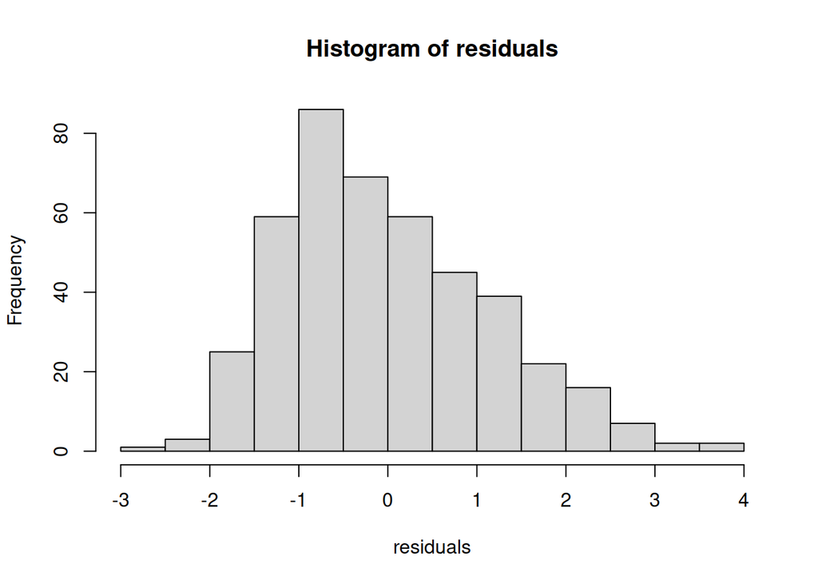

```r
hist(residuals)
```

# 5. Bootstrapping

**5.1 One sample**

Make a new fit with a new dataset of the same size of the original but sampled with replacement. What is the value of the coefficients now?

```r
ids <- sample(nrow(usersdf), replace=T)
bootmodel <- lm(usersdf$SI[ids]~usersdf$FC[ids])
bootmodel
```

```
##
## Call:
## lm(formula = usersdf$SI[ids] ~ usersdf$FC[ids])
##
## Coefficients:
##     (Intercept)  usersdf$FC[ids]
##         -3.4587           0.6192
```

**5.2 Many boostrap samples**

Repeat the bootstrap sample fit of the previous point 10000 times and save the values of the second coefficient in a vector.

```r
bootVs <- rep(0, 10000)
for (i in seq(1,10000))
{
  ids <- sample(x = seq(1,nrow(usersdf)), size = nrow(usersdf), replace=T)
  bootmodel <- lm(usersdf$SI[ids]~usersdf$FC[ids])
  bootVs[i] <- bootmodel$coefficients[2]
}
```

**5.3 Bootstrap histogram**

Plot a histogram of the values resulting from the permutations and a vertical line on the value of the second coefficient of the original data. Use the xlim parameter of hist to make sure that both the histogram and the line can be plotted. How far is the line from the center of the histogram?

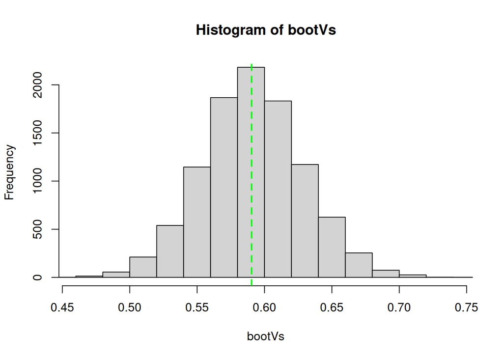

```r
hist(bootVs, xlim=range(c(bootVs, model$coefficients[2])))
abline(v=model$coefficients[2], lty=2, col="green", lwd=2)
```

**5.4 Extra: a version of above with boot()**

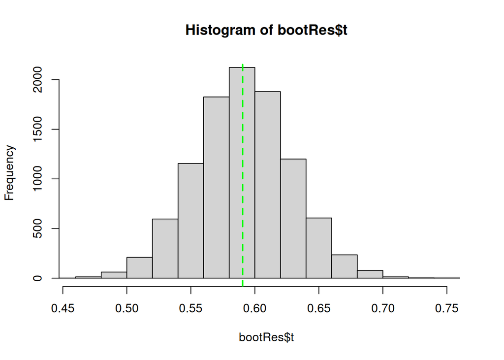

```r
library(boot)

bootSlope <- function(df, ids)
{
  bootmodel <- lm(df$SI[ids]~df$FC[ids])
  return(bootmodel$coefficients[2])
}

bootRes <- boot(data = usersdf, statistic = bootSlope, R = 10000)
hist(bootRes$t, xlim=range(c(bootRes$t, model$coefficients[2])))
abline(v=model$coefficients[2], lty=2, col="green", lwd=2)
```

# Conclusions

1. Do you find any relationship between social impact and the number of followers?
2. How sure are you that it is larger than zero? How sure are you that it is lower than 1?
3. Is the value of the relationship within the ranges predicted by Social Impact Theory?
4. Under that relationship, if I have 1000 followers, how many more followers do I need to double my social impact?
5. What is the problem with the distribution of residuals of the model? Can you link that to the scatter plot with the model fit?